# Stablecoins — compare USDC, USDT and DAI transaction sizes and volumes

We want to compare three major Ethereum stablecoins:

- USDC (smart contract address: 0xa0b86991c6218b36c1d19d4a2e9eb0ce3606eb48)
- USDT (smart contract address: 0xdac17f958d2ee523a2206206994597c13d831ec7)
- DAI (smart contract address: 0x6b175474e89094c44da98b954eedeac495271d0f)

We will investigate two questions:

1. How do their transfer sizes differ?
2. How much transfer volume does each stablecoin generate?

Our workflow is:

```
Ethereum
   ↓
Etherscan
   ↓
ERC-20 transfer events
   ↓
R / tidyverse
   ↓
transfer sizes + transfer volumes
```

We use Etherscan to retrieve the already indexed ERC-20 transfer events. Etherscan’s `tokentx` endpoint can be filtered directly by token contract, so we do not need to download unrelated ERC-20 transfers first.

We use the term transfer rather than transaction throughout the lab: one Ethereum transaction can generate several ERC-20 transfer events.

```r
library(usethis)
edit_r_environ()
```

```r
library(tidyverse)
library(httr2)

# Recuperiamo la chiave API configurata nel .Renviron
api_key <- Sys.getenv("ETHERSCAN_API_KEY")

# Configurazione dei contratti e dei decimali specifici
stablecoin_config <- tibble(
  token = c("USDC", "USDT", "DAI"),
  contract_address = c(
    "0xa0b86991c6218b36c1d19d4a2e9eb0ce3606eb48", # USDC (6 decimali)
    "0xdac17f958d2ee523a2206206994597c13d831ec7", # USDT (6 decimali)
    "0x6b175474e89094c44da98b954eedeac495271d0f"  # DAI (18 decimali)
  ),
  decimals = c(6, 6, 18)
)

# Funzione per interrogare l'endpoint tokentx di Etherscan V2
get_token_transfers <- function(contract_address, token_name, api_key, max_offset = 1000) {
  message("Scaricamento trasferimenti per: ", token_name)

  response <- request("https://api.etherscan.io/v2/api") |>
    req_url_query(
      chainid = 1,
      module = "account",
      action = "tokentx", # Endpoint specifico per eventi ERC-20
      contractaddress = contract_address,
      startblock = 0,
      endblock = 99999999,
      page = 1,
      offset = max_offset,
      sort = "desc",
      apikey = api_key
    ) |>
    req_perform() |>
    resp_body_json(simplifyVector = TRUE)

  if (is.character(response$result)) {
    warning("Nessun dato trovato per: ", token_name)
    return(NULL)
  }

  response$result |>
    as_tibble() |>
    mutate(token_symbol = token_name)
}

# Eseguiamo il download iterativo per tutte e tre le stablecoin
tokens_raw <- map2_dfr(
  stablecoin_config$contract_address,
  stablecoin_config$token,
  ~ get_token_transfers(.x, .y, api_key)
)
```

```r
tokens_clean <- tokens_raw |>
  left_join(stablecoin_config, by = c("contractAddress" = "contract_address")) |>
  mutate(
    time = as.POSIXct(as.numeric(timeStamp), origin = "1970-01-01", tz = "UTC"),
    # Conversione corretta dell'importo reale in USD
    value_real = as.numeric(value) / (10 ^ decimals)
  )
```

## Doamnda 1: Qual è la differenza tra i metodi di trasferiemtno?

```r
size_summary <- tokens_clean |>
  group_by(token_symbol) |>
  summarise(
    n_transfers = n(),
    mean_size   = mean(value_real, na.rm = TRUE),
    median_size = median(value_real, na.rm = TRUE),
    p95_size    = quantile(value_real, 0.95, na.rm = TRUE),
    max_size    = max(value_real, na.rm = TRUE)
  )

size_summary
```

```
## # A tibble: 3 × 6
##   token_symbol n_transfers mean_size median_size p95_size  max_size
##   <chr>              <int>     <dbl>       <dbl>    <dbl>     <dbl>
## 1 DAI                 1000    18635.    402.      124329.   922686.
## 2 USDC                1000   187103.     68.6      11681. 90292063.
## 3 USDT                1000     2611.      0.0280    2837.   550000
```

Le distribuzioni dei trasferimenti sono fortemente asimmetriche. In tutte le stablecoin la media risulta molto maggiore della mediana, indicando la presenza di pochi trasferimenti estremamente grandi. DAI presenta la mediana più elevata e quindi i trasferimenti tipici più grandi. USDC mostra invece la media più alta a causa di alcuni trasferimenti eccezionalmente grandi, superiori a 90 milioni di unità. USDT presenta le dimensioni di trasferimento generalmente più contenute.

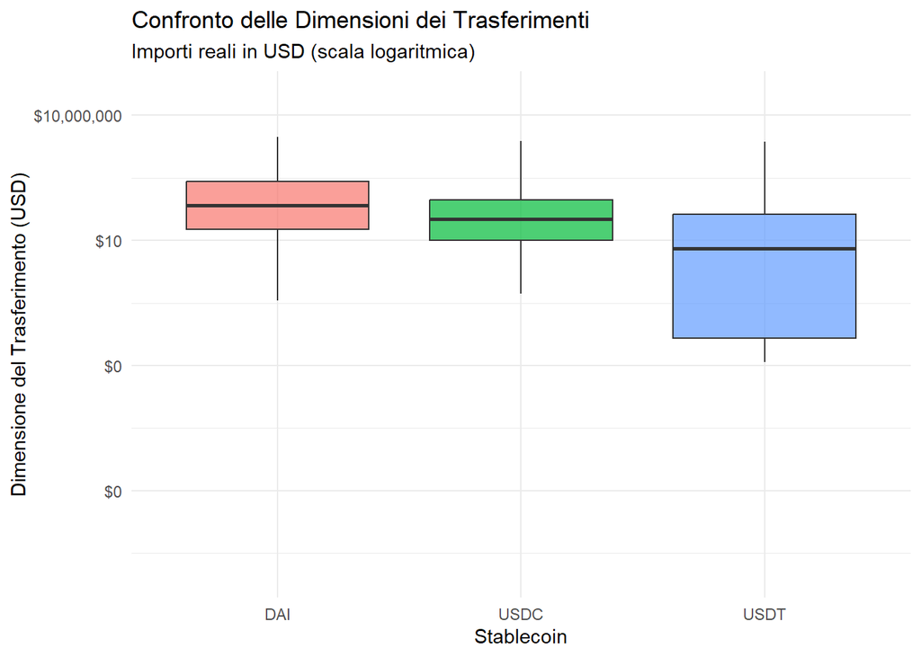

```r
tokens_clean |>
  filter(value_real > 0) |>
  ggplot(aes(x = token_symbol, y = value_real, fill = token_symbol)) +
  geom_boxplot(alpha = 0.7, outlier.shape = NA) +
  scale_y_log10(labels = scales::dollar_format()) +
  labs(
    title = "Confronto delle Dimensioni dei Trasferimenti",
    subtitle = "Importi reali in USD (scala logaritmica)",
    x = "Stablecoin",
    y = "Dimensione del Trasferimento (USD)"
  ) +
  theme_minimal() +
  theme(legend.position = "none")
```

## Domanda 2: Quanto volume di trasferimenti genera ogni stablecoin?

```r
volume_summary <- tokens_clean |>
  group_by(token_symbol) |>
  summarise(
    total_volume = sum(value_real, na.rm = TRUE)
  ) |>
  mutate(
    market_share = (total_volume / sum(total_volume)) * 100
  )

volume_summary
```

```
## # A tibble: 3 × 3
##   token_symbol total_volume market_share
##   <chr>               <dbl>        <dbl>
## 1 DAI             18634632.         8.94
## 2 USDC           187103245.        89.8
## 3 USDT             2610961.         1.25
```

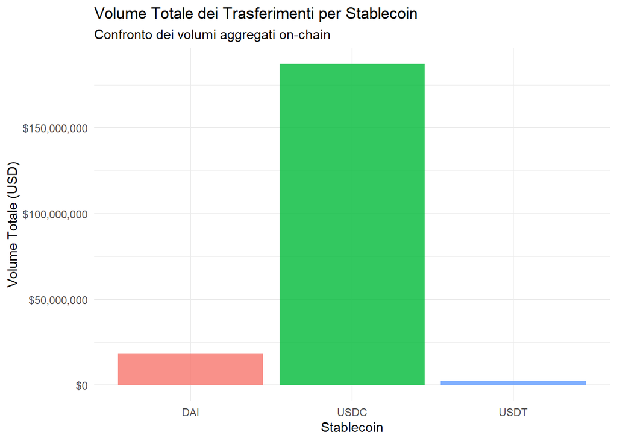

```r
ggplot(volume_summary, aes(x = token_symbol, y = total_volume, fill = token_symbol)) +
  geom_col(alpha = 0.8) +
  scale_y_continuous(labels = scales::dollar_format()) +
  labs(
    title = "Volume Totale dei Trasferimenti per Stablecoin",
    subtitle = "Confronto dei volumi aggregati on-chain",
    x = "Stablecoin",
    y = "Volume Totale (USD)"
  ) +
  theme_minimal() +
  theme(legend.position = "none")
```

### Conclusione:

L’analisi evidenzia differenze significative tra le principali stablecoin di Ethereum. DAI presenta trasferimenti tipici più elevati, come indicato dalla mediana maggiore. USDT mostra invece trasferimenti generalmente più piccoli. USDC domina nettamente il volume totale trasferito, rappresentando circa il 90% del volume osservato nel campione. La presenza di pochi trasferimenti molto grandi influisce fortemente sulle medie, motivo per cui la mediana risulta più rappresentativa della dimensione tipica dei trasferimenti. I risultati si riferiscono ai 1000 eventi ERC‑20 scaricati per ciascun token tramite Etherscan e descrivono pertanto il campione analizzato, non l’intera storia della blockchain.